# Eury_loxo_SEI_model

Alyssa-Lois Gehman

11/20/2017

# Host and parasite thermal ecology jointly determine the effect of climate warming on epidemic dynamics

Authors: Alyssa-Lois M. Gehman, Richard J. Hall and James E. Byers Correspondence to: Alyssa-Lois M. Gehman

# This code produces the seasonal host-parasite dynamics used in manuscript, based on weekly temperature data

*Requirements* a. download and install package deSolve b. download and place folder ‘Gehman_etal_Code_2017’ on your desktop

*1 - Functional fits to the data* These define the best fit model parameters for the temperature dependent rates in the SEI mode, as parameterized from the temperature data, and recreate Figure 1C-E.

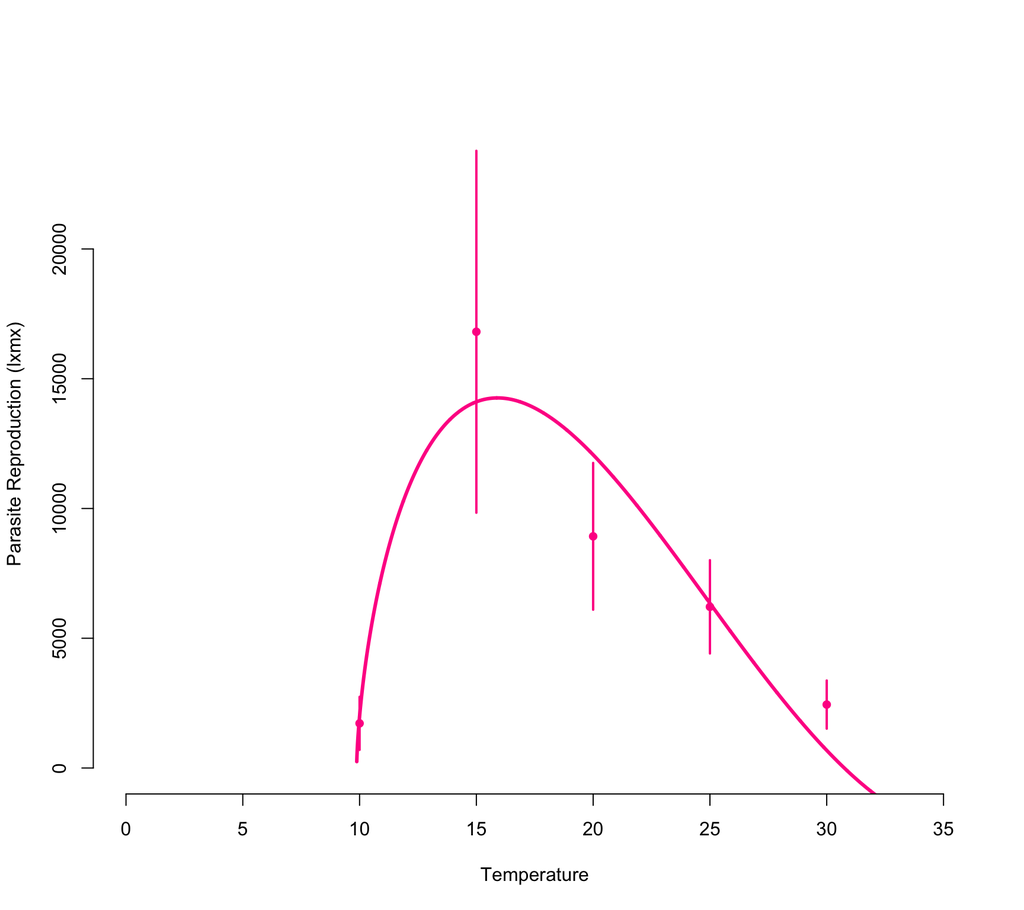

```
## Nonlinear regression model
##   model: lxmx ~ c * (-temp + T0 + Tm) * (Tm - temp) * (temp - T0)^(0.65)
##    data: beta.data
##      c     T0     Tm
## 12.083  9.875 30.753
##  residual sum-of-squares: 20354198
##
## Number of iterations to convergence: 2
## Achieved convergence tolerance: 4.98e-06
```

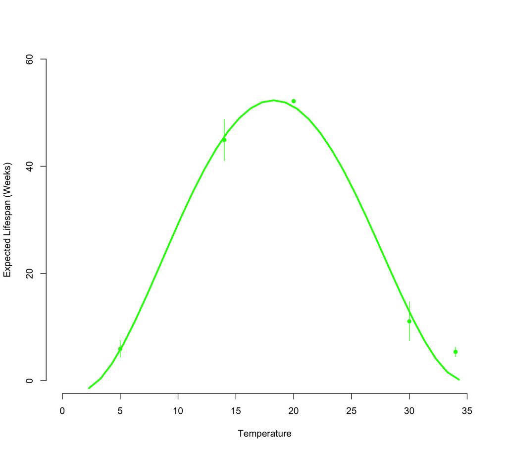

```
## Nonlinear regression model
##   model: S.surv ~ c * S.temp * (S.temp - T0) * (Tm - S.temp)^(2)
##    data: S.data
##         c        T0        Tm
## 6.923e-04 3.136e+00 3.480e+01
##  residual sum-of-squares: 28.72
##
## Number of iterations to convergence: 11
## Achieved convergence tolerance: 8.296e-06
```

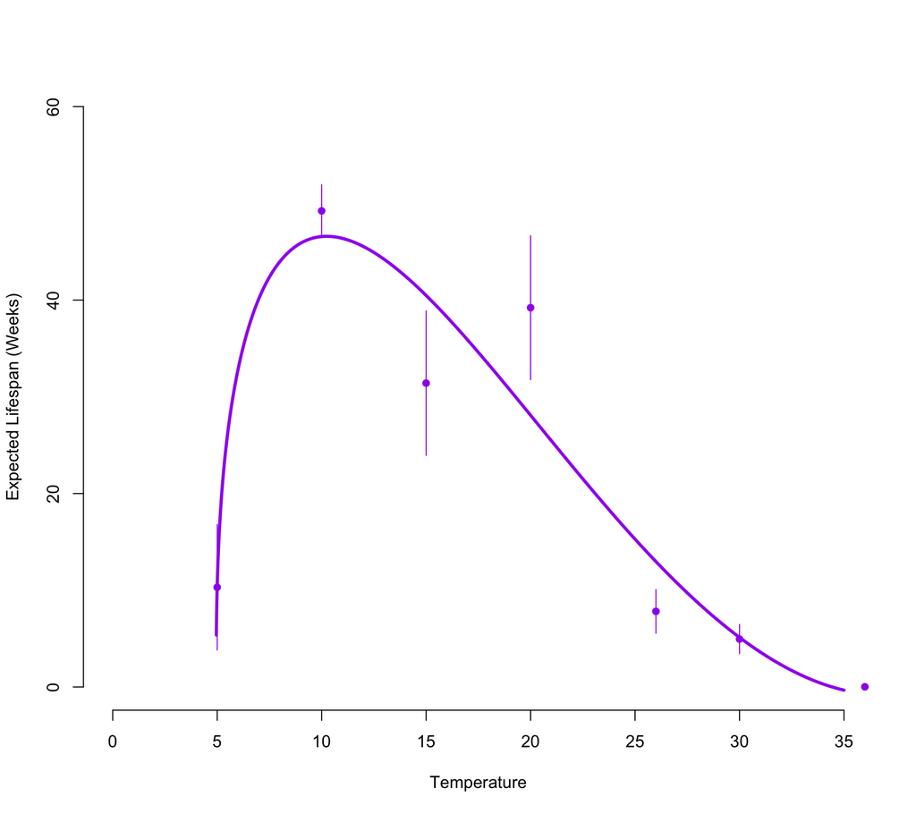

```
## Nonlinear regression model
##   model: E.surv ~ c * (-E.temp + T0 + Tm) * (Tm - E.temp) * (E.temp -     T0)^(0.4)
##    data: E.data
##        c       T0       Tm
##  0.03393  4.95039 34.43724
##  residual sum-of-squares: 240
##
## Number of iterations to convergence: 4
## Achieved convergence tolerance: 5.339e-07
```

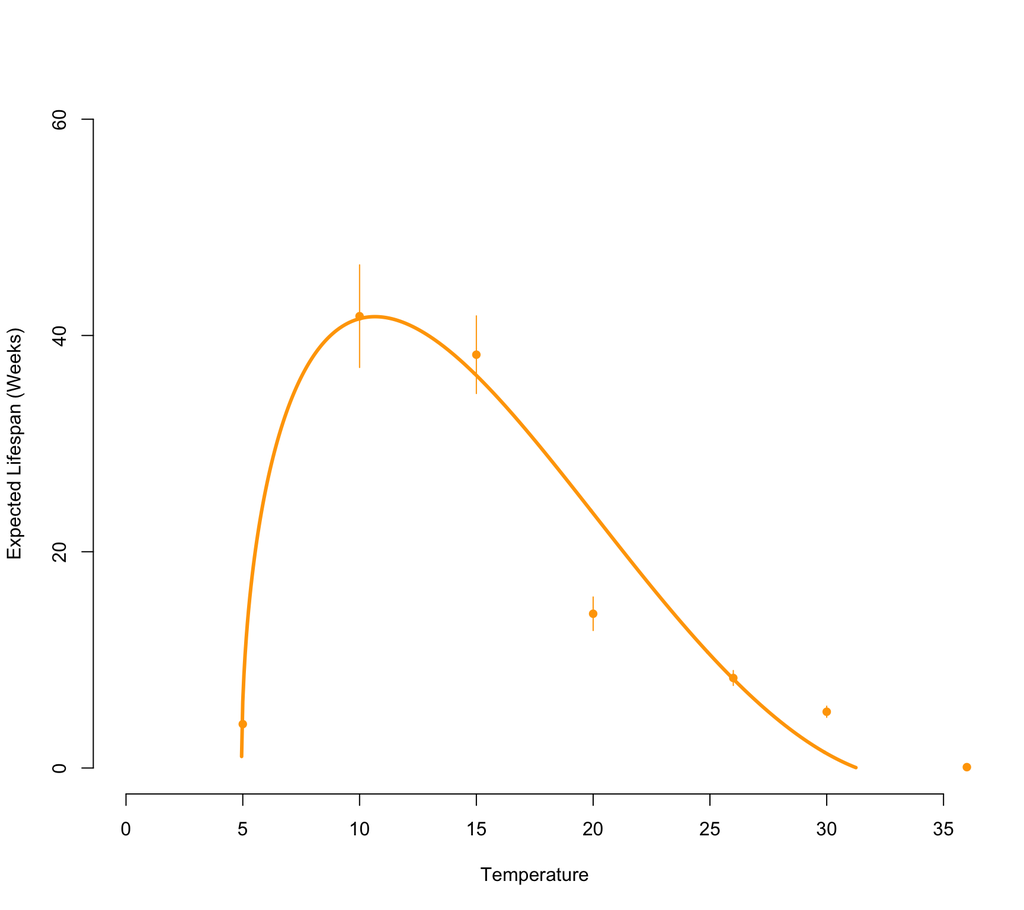

```
## Nonlinear regression model
##   model: I.surv ~ c * (-I.temp + T0 + Tm) * (Tm - I.temp) * (I.temp -     T0)^(0.3)
##    data: I.data
##        c       T0       Tm
##  0.04414  4.99944 32.10496
##  residual sum-of-squares: 78.6
##
## Number of iterations to convergence: 5
## Achieved convergence tolerance: 5.604e-06
```

*2 - The model equations*

Must be run for sections 3 and 4 to work.

*3 - Evaluating climate change effects with the model*

Below we use thermal performance curves (Section 1) to parameterize how host mortality and transmission rates depend on weekly mean temperatures; the other parameters were estimated from the literature, or chosen to give good quantitative agreement with field data on host abundance and infection prevalence by season and subject to extensive sensitivity analyses (methods C.ii and iii).

The temperatures used are mean weekly temperatures from a mooring that is part of the Georgia Coastal Ecosystems Long Term Ecological Research program (GCE-LTER) that measured temperature at a depth of ~1m (temp0), the approximate depth of water found over an oyster reef in Georgia, and thus the thermal environment experienced by E. depressus and L. panopaei.

The model runs with ambient temperature (temp0), then ambient +1 and +2ºC (temp1 and temp2), then the mean temperature change from 1970-2008 (temp1.6) and seasonally varying change (temp.season) from 1970-2008 (tempseas).

To run this code, first run the code in section 2.

*4 Plotting climate change effects*

This code using the model output from section 3 and creates Figure 3. For this code to work first section 2 and 3 must have been run.

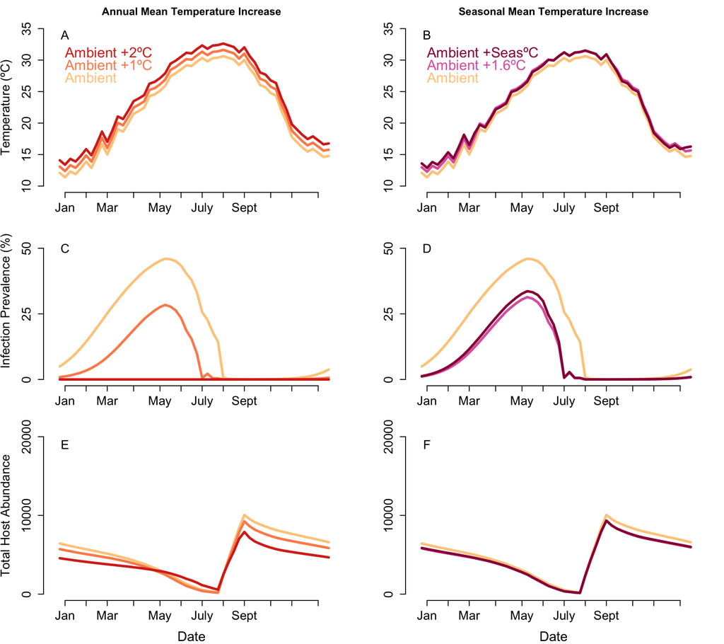